# GEOG 6000 Lab Plotting with ggplot2

Simon Brewer

August 31, 2020

The base installation of R contains several functions for plotting and visualizing data. In addition to these, there are several add-on packages that greatly extend the basic functionality. Here, we will look at one of the most widely used of these, **ggplot2**. Before starting the lab, you will need to set up a new folder for your working directory. Go to your `geog6000` folder now and create a new folder for today’s class called `lab05b`. Make sure to set this to the working directory with `setwd()`. As a reminder, you can also do this by going to the [Session] menu in RStudio, then [Change working directory]. This will open a file browser that you can use to browse through your computer and find the folder.

The [**ggplot2**](https://ggplot2.tidyverse.org/) package was written by Hadley Wickham, and implements the [Grammar of Graphics](http://www.springer.com/us/book/9780387245447) framework developed by Leland Wilkinson. The idea behind the grammar of graphics is that all plots can be described by a common language, rather than considering them as separate barplots, line charts, etc. What differs is the coordinate system and *geometry* used to place the data on the page. Using this package requires a little more work than standard plots, but the results are usually worth while.

The **ggplot2** package comes with two main functions: `qplot()`, a simple plotting routine which is designed to replace the base `plot()` function in R; and `ggplot()`, which provides a much greater range of functions. We’ll look briefly at the first of these before looking at `ggplot()` in more detail.

Start by installing and loading the **ggplot2** package:

```r
install.packages("ggplot2")
library(ggplot2)
```

You will need to download these files from Canvas, and move them from your `Downloads` folder to the `datafiles` folder that you made previously. Then load these data sets and use `str()` and `names()` to look at what they contain:

```r
penguins <- read.csv("../datafiles/penguins.csv")
str(iris)
```

```
## 'data.frame':    150 obs. of  5 variables:
##  $ Sepal.Length: num  5.1 4.9 4.7 4.6 5 5.4 4.6 5 4.4 4.9 ...
##  $ Sepal.Width : num  3.5 3 3.2 3.1 3.6 3.9 3.4 3.4 2.9 3.1 ...
##  $ Petal.Length: num  1.4 1.4 1.3 1.5 1.4 1.7 1.4 1.5 1.4 1.5 ...
##  $ Petal.Width : num  0.2 0.2 0.2 0.2 0.2 0.4 0.3 0.2 0.2 0.1 ...
##  $ Species     : Factor w/ 3 levels "setosa","versicolor",..: 1 1 1 1 1 1 1 1 1 1 ...
```

```r
orange <- read.csv("../datafiles/orange.csv")
str(orange)
```

```
## 'data.frame':    35 obs. of  3 variables:
##  $ Tree         : int  1 1 1 1 1 1 1 2 2 2 ...
##  $ age          : int  118 484 664 1004 1231 1372 1582 118 484 664 ...
##  $ circumference: int  30 58 87 115 120 142 145 33 69 111 ...
```

```r
gapdata <- read.csv("../datafiles/gapminderData5.csv")
str(gapdata)
```

```
## 'data.frame':    1704 obs. of  6 variables:
##  $ country  : chr  "Afghanistan" "Afghanistan" "Afghanistan" "Afghanistan" ...
##  $ year     : int  1952 1957 1962 1967 1972 1977 1982 1987 1992 1997 ...
##  $ pop      : num  8425333 9240934 10267083 11537966 13079460 ...
##  $ continent: chr  "Asia" "Asia" "Asia" "Asia" ...
##  $ lifeExp  : num  28.8 30.3 32 34 36.1 ...
##  $ gdpPercap: num  779 821 853 836 740 ...
```

```r
VADeaths <- read.csv("../datafiles/VADeaths.csv")
str(VADeaths)
```

```
## 'data.frame':    5 obs. of  5 variables:
##  $ Age         : chr  "50-54" "55-59" "60-64" "65-69" ...
##  $ Rural.Male  : num  11.7 18.1 26.9 41 66
##  $ Rural.Female: num  8.7 11.7 20.3 30.9 54.3
##  $ Urban.Male  : num  15.4 24.3 37 54.6 71.1
##  $ Urban.Female: num  8.4 13.6 19.3 35.1 50
```

# Reshaping tables for plotting

**ggplot2** is part of an *opinionated* ecosystem of R packages called the [**Tidyverse**](https://www.tidyverse.org/). Without going too far into the weeds, one of its core tenets is that data should be in *long* format, so all of its R packages just assume that the data have this form, including **ggplot2**. What does this mean exactly? Well, have a look at the VADeaths table again. It is currently in a wide format:

```r
VADeaths
```

```
##     Age Rural.Male Rural.Female Urban.Male Urban.Female
## 1 50-54       11.7          8.7       15.4          8.4
## 2 55-59       18.1         11.7       24.3         13.6
## 3 60-64       26.9         20.3       37.0         19.3
## 4 65-69       41.0         30.9       54.6         35.1
## 5 70-74       66.0         54.3       71.1         50.0
```

Here, we have a *categorical* column for each demographic class: (i) rural and male, (ii) rural and female, (iii) urban and male, and (iv) urban and female. And the values in each cell represent the death rate for that demographic class and age range. To make this table long form (to reshape it), we would want four columns: Age, Residence, Gender, and Death Rate; with the Residence and Gender columns containing the data held unhelpfully in the column names.

One very useful R package for reshaping tables in this way is [**tidyr**](https://tidyr.tidyverse.org/index.html), whose primary functions are `pivot_wider` and `pivot_longer`, which reshape the data into wide and long formats, respectively.

```r
library(tidyr)

VADeaths2 <- pivot_longer(VADeaths,
                          cols = Rural.Male:Urban.Female,
                          names_to = c("Residence", "Gender"),
                          names_sep = "\\.",
                          values_to = "DeathRate")

VADeaths2
```

```
## # A tibble: 20 x 4
##    Age   Residence Gender DeathRate
##    <chr> <chr>     <chr>      <dbl>
##  1 50-54 Rural     Male        11.7
##  2 50-54 Rural     Female       8.7
##  3 50-54 Urban     Male        15.4
##  4 50-54 Urban     Female       8.4
##  5 55-59 Rural     Male        18.1
##  6 55-59 Rural     Female      11.7
##  7 55-59 Urban     Male        24.3
##  8 55-59 Urban     Female      13.6
##  9 60-64 Rural     Male        26.9
## 10 60-64 Rural     Female      20.3
## 11 60-64 Urban     Male        37
## 12 60-64 Urban     Female      19.3
## 13 65-69 Rural     Male        41
## 14 65-69 Rural     Female      30.9
## 15 65-69 Urban     Male        54.6
## 16 65-69 Urban     Female      35.1
## 17 70-74 Rural     Male        66
## 18 70-74 Rural     Female      54.3
## 19 70-74 Urban     Male        71.1
## 20 70-74 Urban     Female      50
```

There are three important arguments to `pivot_longer` in addition to stating what columns to pivot. First, `names_to` specifies the names of new columns for demographic class data. Second, `names_sep` specifies the character for separating the column names as values into the respective columns; in this case, the period (‘.’), which is a reserved expression and thus needs to be escaped with two back ticks (‘\’). Finally, `values_to` specifies the name of the new column for death rate data.

# Simple plots with `qplot()`

## Scatterplots

A basic scatterplot. Note that the syntax matches the original `plot()` function, with the $x$ variable specified first, and the $y$ variable second, but the output is quite different:

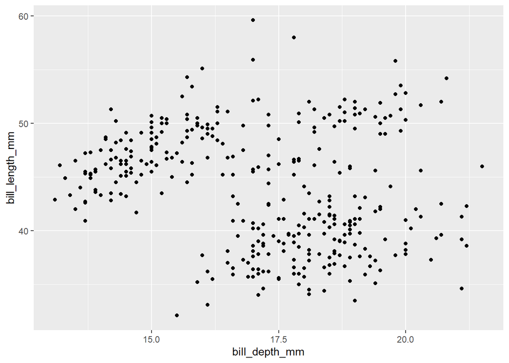

```r
qplot(bill_depth_mm,
      bill_length_mm,
      data = penguins)
```

Coloring the symbols by species (note that a legend is automatically added):

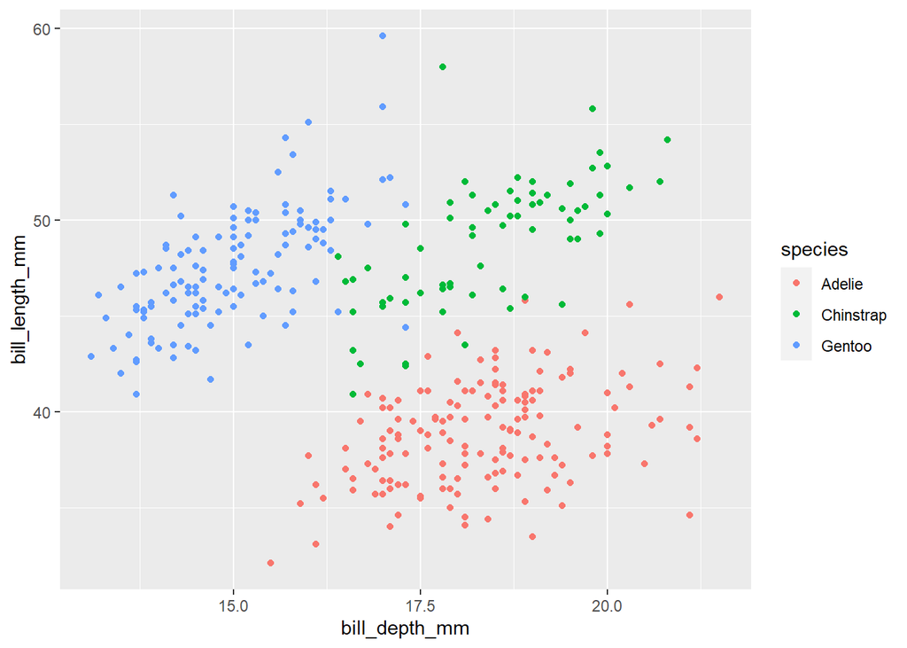

```r
qplot(bill_depth_mm,
      bill_length_mm,
      data = penguins,
      color = species)
```

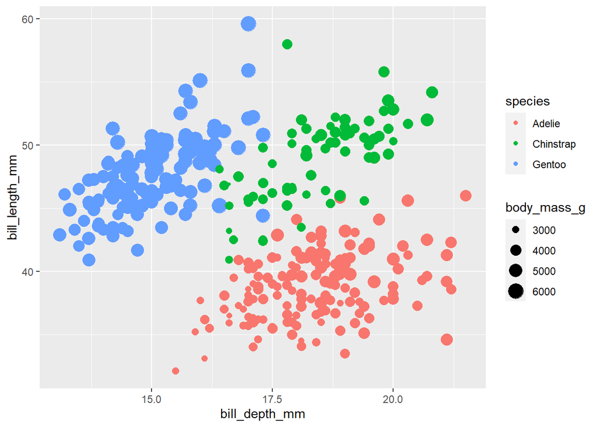

```r
qplot(bill_depth_mm,
      bill_length_mm,
      data = penguins,
      color = species,
      size = body_mass_g)
```

Finally, we add labels and a title, and make the symbols transparent using the parameter `alpha`, in order to make it clear where these overlap:

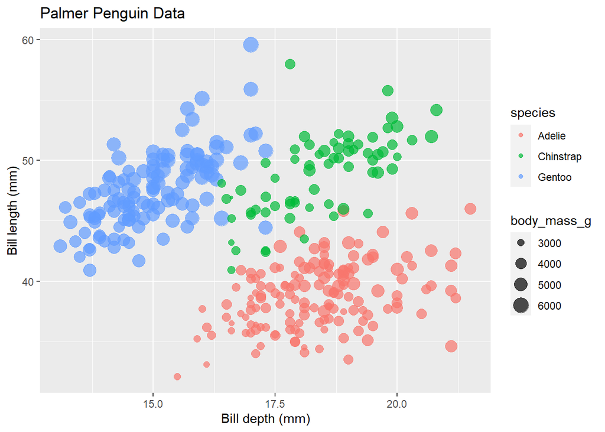

```r
qplot(bill_depth_mm,
      bill_length_mm,
      data = penguins,
      color = species,
      size = body_mass_g,
      alpha = I(0.7),
      xlab = "Bill depth (mm)",
      ylab = "Bill length (mm)",
      main = "Palmer Penguin Data")
```

By default, `qplot()` makes a scatterplot, but this can be changed to a different plot type or geometry, by using the `geom` argument. For example, to make a histogram:

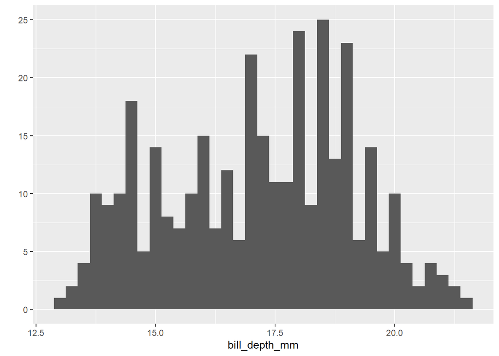

```r
qplot(bill_depth_mm,
      data = penguins,
      geom = 'histogram',
      binwidth = 0.25)
```

Or a set of boxplots:

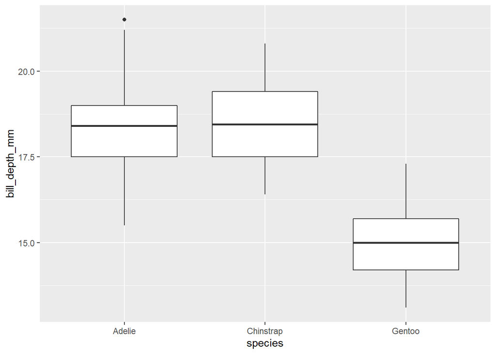

```r
qplot(species,
      bill_depth_mm,
      data = penguins,
      geom = 'boxplot')
```

Line plots can be made with `geom = "line"`. Try this with the set of Orange trees:

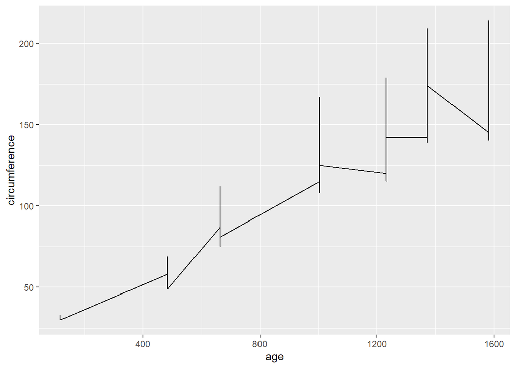

```r
qplot(age,
      circumference,
      data = orange,
      geom = 'line')
```

As this is plotting the circumference from all five trees in the dataset together, the line doesn’t make much sense. We can separate out the different trees by telling `qplot` to use the tree number as a color. As this is a continuous variable, we first convert this into a factor to indicate the different groups (trees):

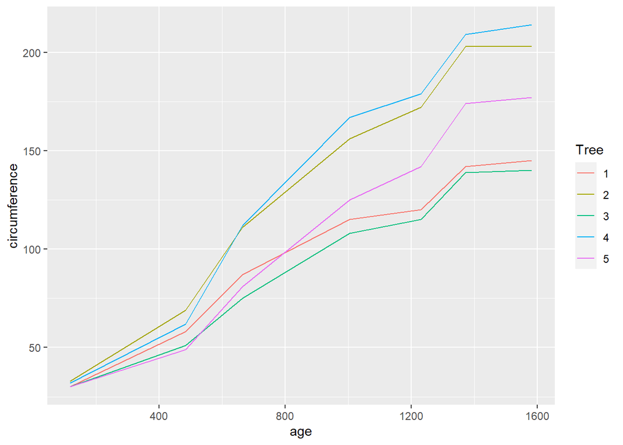

```r
orange$Tree = factor(orange$Tree)
qplot(age,
      circumference,
      data = orange,
      color = Tree,
      geom = 'line')
```

# More advanced figures with `ggplot()`

The `ggplot()` function offers more control over your plots. It works in quite a different way to the other plotting functions, that start with a base plot, then add other points, lines, etc to the figure. Instead, `ggplot` creates a plot *object*, which can be adjusted and added to as you proceed.

In order to understand how `ggplot` makes a figure, we need to establish what the fundamental parts are of every data graph. They are:

1. Aesthetics – these are the roles that the variables play in each graph. A variable may control where points appear, the color or shape of a point, the height of a bar and so on.
2. Geometries – these are the geometric objects which represent the data: points, lines, bars, …
3. Statistics – these are the functions which add some interpretation to the data, e.g. best fit line, location of median, etc
4. Scales – these are legends that show the relationship between variables and different symbols or colors (e.g. circular symbols represent females while squares represent males)
5. Facets – these are groups in your data which may be used to make multiple graphs, each for one of the groups. For example, faceting by gender would cause the graph to repeat for the two genders.

```r
myplot <- ggplot(penguins, aes(x = bill_depth_mm, y = bill_length_mm))
```

If you now type `myplot` at the command line, R will complain that there are no layers in the plot. This is because we need to tell `ggplot` what geometry to use. To do this, we simply ‘add’ one of `ggplot`’s geometry functions. In this case, we use `geom_point()`, to make a scatterplot:

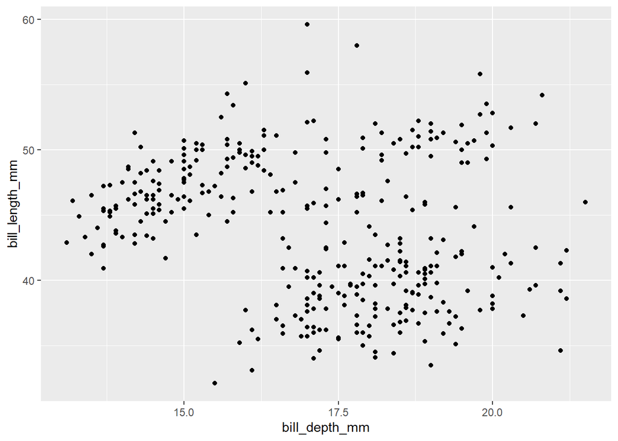

```r
myplot + geom_point()
```

A very important thing to note is that this has not changed our base object `myplot`, but simply displayed it with the point geometry added to it. If you retype `myplot` at the command line, you will again be told that there are no layers. In order to make this change stick (i.e. keep the use of the point geometry), we need to resave the plot object:

```r
myplot <- myplot + geom_point()
```

Now typing `myplot` makes the plot appear. This allows you to experiment with different displays, and only update (or resave) the plot object when you have changes that you want to keep.

We could now add other geometries, statistics or other effects to the plot figure to change the way that it looks. Instead, we’ll work through several different examples now, using the Gapminder dataset to look at the different functions that are available.